# Maintain your brain, Primary Cognitive Composite Variable

CACE analysis

## cogmeanz_full

- Primary Cognitive Composite Variable
  - Cogstate Detection
  - Cogstate Identification
  - Cogstate One Back
  - Cambridge Brain Sciences Spatial (tokens) Search
  - Cambridge Brain Sciences Grammatical Reasoning
  - Cogstate One Card Learning
  - Cambridge Brain Sciences Paired Associates

These analyses use `bl_adritotal` (as named in the original SPSS file) as the ADRI baseline covariate.

These results exclude those participants who were eligible for fewer than 2 modules but who were randomised. This results in N=6104.

This is the analysis for the complier-averaged causal effect. In this analysis, randomisation group is used as an instrumental variable.

- Define “complience”, which can be thought of as whether the treatment was received (and done by the participant).
  - In the intervention group, we will define this as completing at least 60% of content for all eligible modules.
  - In the control group, they are all assume to have 0 treatment received no treatment (`tx_received`=0)
- Two stage process:
  - Regress `tx_received` on randomisation group and save probabilities.
  - Predict outcome from probabilities
  - Estimate the effect (this is the CACE estimate)
  - Bootstrap CIs

Inference for differences in rc_trial_time trend by group_type_id for cogmeanz_full

## Data summary

```
## # A tibble: 8 x 5
## # Groups:   rc_trial_time [4]
##   rc_trial_time group_type_id    Mean    Sd N_obs
##           <int>         <int>   <dbl> <dbl> <int>
## 1             1             1  0.0192 1.00   3053
## 2             1             2 -0.0192 0.996  3051
## 3            10             1  0.228  1.00   2281
## 4            10             2  0.389  1.02   1612
## 5            11             1  0.206  0.994  2014
## 6            11             2  0.406  1.02   1428
## 7            12             1  0.115  1.02   2046
## 8            12             2  0.319  1.06   1442
```

## Defining Compliance groups

# Predict compliance from group (for baseline only)

```
## # A tibble: 2 x 5
##   group_type_id  Mean    SD   Min   Max
##           <int> <dbl> <dbl> <dbl> <dbl>
## 1             1 0     0         0     0
## 2             2 0.224 0.417     0     1
```

[output not shown]

[output not shown]

```
## [1] 0.8098857
```

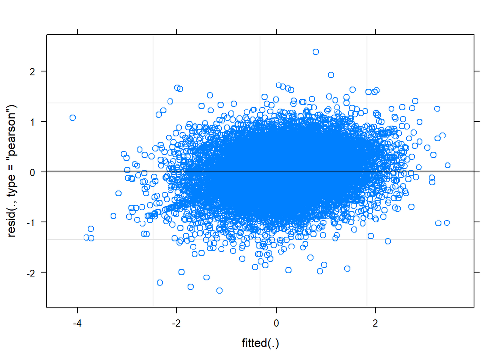

## Bootstrap

https://stackoverflow.com/questions/11919808/block-bootstrap-from-subject-list

```
##        response adjusted base_3yr_did   LCL   UCL p.value
## 1 cogmeanz_full       No         0.81 0.393 1.147  <0.001
```

## Result

We classified someone as “engaged” if they competed at least 60% of units within every module for which they were eligible.

The association of the engagement on outcomes was analysed using a complier average causal effect (CACE) analysis with randomisation group as instrumental variable (Dunn 2005) using a two-step approach with block bootstrap percentile confidence intervals. The first step predicts engagement from randomisation group with a logistic regression. The second step is a linear mixed model with with time, predicted engagement score and their interaction as predictors.

The unadjusted difference in difference value from baseline to three year follow up was 0.81 ( 95%CI: 0.393- 1.147, p<0.001) baseline standard deviations.

Analysis by Nancy Briggs and Gordana Popovic on 2024-02-14

## Reference

Dunn G, Maracy M, Tomenson B. Estimating treatment effects from randomized clinical trials with noncompliance and loss to follow-up: the role of instrumental variable methods. Stat Methods Med Res. 2005 Aug;14(4):369-95. doi: 10.1191/0962280205sm403oa. PMID: 16178138.